# Logistic Regression in R

## [Back](http://henrikeckermann.pythonanywhere.com/)

#### Abbreviations

$\epsilon$ = error term of a model  
OLS = Ordinary least squares  
ML = Maximum Likelihood

## The logistic regression model

When the outcome variable is dichotomous, we can use logistic regression instead of linear regression. Since the relationship between the predictors and the outcome cannot be linear with a dichotomous outcome, a link function is used as illustrated below. Different books use different equations/descriptions for the logistic regression model. This can be confusing sometimes but they all refer to either the probability that y=1, given the predictor(s) X or they refer to the expected value of Y, given X:

**Hosmer & Lemeshow (2000):**

$$E(Y|x) = \pi(x) = \frac{e^{\beta_0+\beta_1x}}{1+e^{\beta_0+\beta_1x}}$$

$$g(x) = ln [\frac{\pi(x)}{1-\pi(x)}] = \beta_0+\beta_1x$$

**Field (2012):**

$$P(Y) = \frac{1}{1+e^{-(b_0+b_1X_1 +b_2X_2 + ... b_iX_i)}}$$

**James, Witten, Hastie, & Tibshirani (2013):**

$$P(Y|X) = \frac{e^{a+b_1X_1+...+b_pX_p}}{1+e^{a+b_1X_1+...+b_pX_p}}$$

**Gelman & Hill (2007):**

$$Pr(y_i = 1) = logit^{-1}(X_i\beta)$$

↓

$$Pr(y_i = 1) = logit^{-1}(\beta_0 + \beta_1X_1 + ...\beta_iX_i)$$

The function $logit^{-1}(x) = \frac{e^x}{1+e^x}$ transforms continuous values to the range (0,1). Thus, using this function for the linear function $X_i\beta$ results in the equation used by James et al. (2013). Gelman & Hill (2007) prefer to work with $logit^{-1}$ because it focuses on the mapping from the linear predictor to the probabilities, rather than the reverse. To clarify this further, they once more write this up in a different way:

$Pr(y=1) = p_i$ and $logit(p_i) = X_i\beta$

## Comparison with linear regression

In linear regression, the outcomes are assumed to be normally distributed with an $E(Y|X)$. The error term $\epsilon$ results from subtracting that conditional mean from the outcome and is assumed to be independent of the predictor variables X and to follow a normal distribution with $\mu=0$ and similar variance $\sigma^2$ across all observations. In logistic regression, the observations $y\in\{0,1\}$ are assumed to follow a Bernoulli distribution, again with a $mean= E(Y|X)$. $E(Y|X)$ for a Bernoulli random variable is the probability $p$ of the event happening. There is no common error distribution that is independent of the predictor values. For the prediction of $y_i$ given predictor(s) $X_i$, the error is $1-\pi$ occurring with probability $\pi$, and $0-\pi$ occurring with probability $1-\pi$.  
To fit a linear regression model, the method of *least squares* (OLS) is used most often. This method finds the parameters **$\beta_i$** that minimize $\sum_{i=1}^n (y_i - \hat{y}_i)^2$. Under the assumption of $\varepsilon$ ~ $N(0,\delta^2)$, OLS yields estimators with certain desirable properties. However, when the outcome is a dichotomous variable, this is not the case, which is why *maximum likelihood estimation* (ML) (that also leads to the least squares function if $\varepsilon$ ~ $N(0,\delta^2)$) is used. Simply said, ML provides estimates for the parameters of a model that make the data most likely. Despite these differences, the general principles that guide us when we perform linear regression also guide us through logistic regression.

## Interpreting the coefficients

We do not try to interpret the statistical significance of the intercept. Gelman & Hill (2007) provide a R package called *arm* (Gelman & Su, 2016) that can be helpful for the interpretation of the coefficients. Whereas in linear regression, a change of 1 unit in the predictor $X_i$ (holding other predictors constant) would always lead to a change of the predicted value $\hat{y}$ by the slope $\beta_i$, in logistic regression we can see that this is different when looking at the first example in the code block below. We see there that if we would add ~0.4 to the logit scale of P(Y|X), this translates to a change in probability of 10% in one case but 3% in the other case due to the non-linearity. Comment out the following code and try for yourself:

```r
library(arm)
##Example 1:
## A change of ??X by ~.4 is equivalent to a 10% change in P(Y|X):
#print(logit(0.5))
#print(logit(0.6))
#print(logit(0.5)-logit(0.6))
## or when we get near the boundaries (here 1) to a change of 3%:
#print(logit(0.9))
#print(logit(0.93))
#print(logit(0.9)-logit(0.93))
```

In the example of the book, the model is $logit^{-1} = -1.4+0.33X$. Thus, a one unit change in x, corresponds to a 0.33 positive change in the logit of the probability of Y. To better grasp what this means, we can for example look at how a one unit change in x near the mean (here: $\bar{x} = 3.1$) (e.g. one unit change from 3 to 2) changes P(Y|x). Here, this results in a change of ~ 8% (see Gelman & Hill (2007) for content of that example, but I will present a full example further below).

```r
##Example 2:
#A 1 unit change in x (here from 3 to 2) results in a change in P(Y|X) of:
p_change <- invlogit(-1.4+0.33*3) - invlogit(-1.4+0.33*2)
# A 1 unit change (here from 1 to 2) results in a change in P(Y|X) of:
p_change_2 <- invlogit(-1.4+0.33*2) - invlogit(-1.4+0.33*1)
##Generally evaluating P(Y|x) at the mean
#invlogit(coef(fit.1)[1] + coef(fit.1)[2]*mean(income))
cat(p_change,',', p_change_2)
```

```
## 0.07590798 , 0.06760106
```

Gelman & Hill (2007) also show that you could calculate the slope at one point for interpretation. More applicable I found the following rule of thumb: Divide $\beta_i$ by 4 to get the maximum change in probability for one unit change in the corresponding x. This upper bound is a reasonable approximation (only) near the midpoint of the logistic curve where P(Y|X) is close to 0.5. Another way of interpretation is using the **odds ratio**. The odds of an event are $\frac{p}{1-p}$. The ratio of two odds is called the odds ratio. An exponentiated logistic regression coefficient can be interpreted as an odds ratio and the change in odds resulting from a unit change in the corresponding predictor. If the odds ratio >1, then the odds get higher with a unit increase of the predictor and vice versa. This has implications also for the interpretation of the confidence intervals of the odds ratio. Not zero but one is the critical value here.

## Example

Let us now consider the example that Gelman & Hill (2007) present in their book. The following measures have been taken to predict whether people living in Bangladesh switch their well due to arsenic levels:

|  | switch | arsenic | dist | assoc | educ | dist100 |
| --- | --- | --- | --- | --- | --- | --- |
| 1 | 1 | 2.36 | 16.826 | 0 | 0 | 0.16826 |
| 2 | 1 | 0.71 | 47.322 | 0 | 0 | 0.47322 |
| 3 | 0 | 2.07 | 20.967 | 0 | 10 | 0.20967 |
| 4 | 1 | 1.15 | 21.486 | 0 | 12 | 0.21486 |
| 5 | 1 | 1.10 | 40.874 | 1 | 14 | 0.40874 |
| 6 | 1 | 3.90 | 69.518 | 1 | 9 | 0.69518 |

**Outcome:**  
*Switch*:  
Whether or not a household switched well

**Features:**  
*Arsenic*:  
Arsenic load of well  
*Dist*:  
Distance to the next good well (originally in m but this is rescaled here (dist100) because the coefficient would be very small, which is misleading)  
*Assoc*:  
1 if a household member is in any community organizations  
*Educ*:  
Years of education of well user

To get an overview of our continuous predictors, lets take a look at their distribution

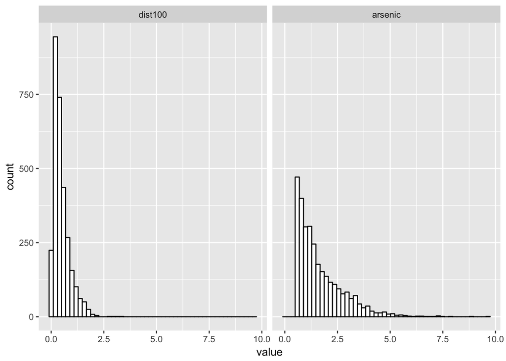

```r
library(reshape2)
df_l <- melt(df,measure.vars=c('dist100', 'arsenic'), id.vars=c('assoc','educ'), value='switch')
#histogram of predictor distance to nearest safe well
library(ggplot2)
ggplot(df_l, aes(value)) +
  geom_histogram(col='black', fill='white', bins=50) +
  facet_wrap(~variable)
```

```r
#Fit model
library(arm)
fit_1 <- glm(switch ~ dist100, data= df, family=binomial(link='logit'))
display(fit_1)
```

```
## glm(formula = switch ~ dist100, family = binomial(link = "logit"),
##     data = df)
##             coef.est coef.se
## (Intercept)  0.61     0.06
## dist100     -0.62     0.10
## ---
##   n = 3020, k = 2
##   residual deviance = 4076.2, null deviance = 4118.1 (difference = 41.9)
```

Thus, our model is: $P(switch=1|dist) = logit^{-1}(0.61 -0.62*dist100)$

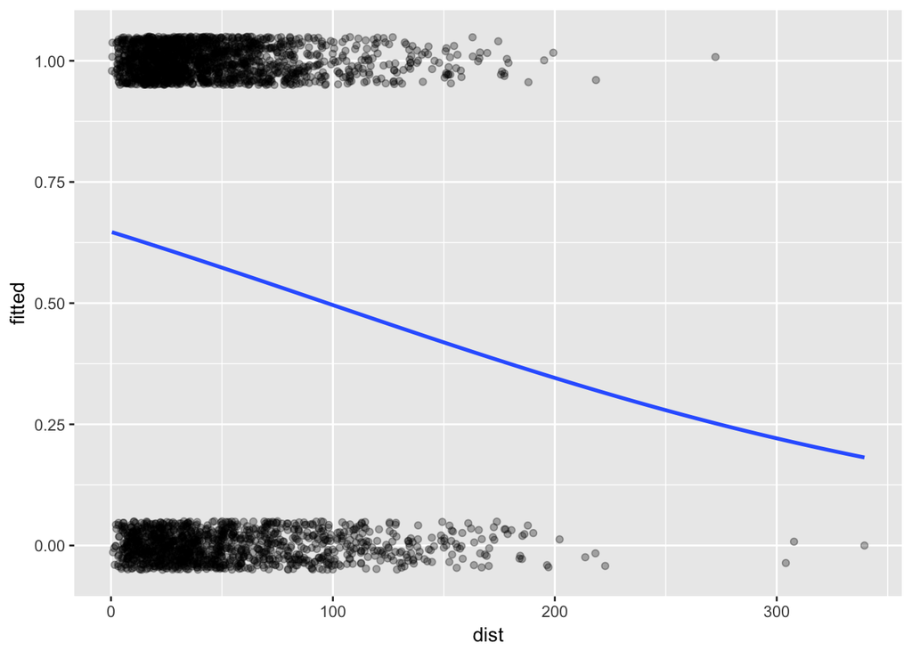

```r
#Plot fitted model
df$fitted <- fit_1$fitted.values
ggplot(df, aes(x=dist, y=fitted)) +
  geom_smooth(method = "glm", method.args = list(family = "binomial"), se = FALSE) +
  geom_jitter(data=df, aes(y=switch), alpha=0.3, height=0.05)
```

The intercept can be interpreted as follows:  
$P(switch=1|dist=0) = logit^{-1}(0.61-0.62*0) = logit^{-1}(0.61) =$ 0.6479408. Remember also the divide by 4 rule: $0.62/4 =$ -0.155, thus, a change in dist100 of of 1 (100m) will lead maximal to a reduction of -0.155 in P(switch=1|dist100) and that most accurate near the mean of dist100 (48.33). Looking at the significance of the coefficient of dist100 we see that it is highly significant. The standard error is small compared to the coefficient:

```r
#Add Arsenic
fit_2 <- glm(switch ~ dist100 +arsenic, data=df, family=binomial(link='logit'))
display(fit_2)
```

```
## glm(formula = switch ~ dist100 + arsenic, family = binomial(link = "logit"),
##     data = df)
##             coef.est coef.se
## (Intercept)  0.00     0.08
## dist100     -0.90     0.10
## arsenic      0.46     0.04
## ---
##   n = 3020, k = 3
##   residual deviance = 3930.7, null deviance = 4118.1 (difference = 187.4)
```

Again, quickly interpreting with the divide by four rule, we notice that the change in P(Y|X) is maximal -22.42% for dist100 and 11.52% for arsenic. Important: It seems as if distance is a more important predictor. However, we need to consider that the standard deviation of dist100 is 0.38 whereas arsenic has a higher standard deviation of 1.11. Multiplying the coefficients by the standard deviation of the corresponding variable yields how much they contribute in 1-SD differences (dist100 = -0.34, arsenic = 0.51). Dividing by 4 again shows how much a 1-SD change would influence the P(switch=1) (8% vs 13%) maximal.

Plotting two predictors could be done using a 3-dimensional plot but I follow the advice of Gelman & Hill (2007) that these are difficult to read and that it is a better idea to make two plots where we show different lines corresponding to fixed reasonable values for the other predictor variable:

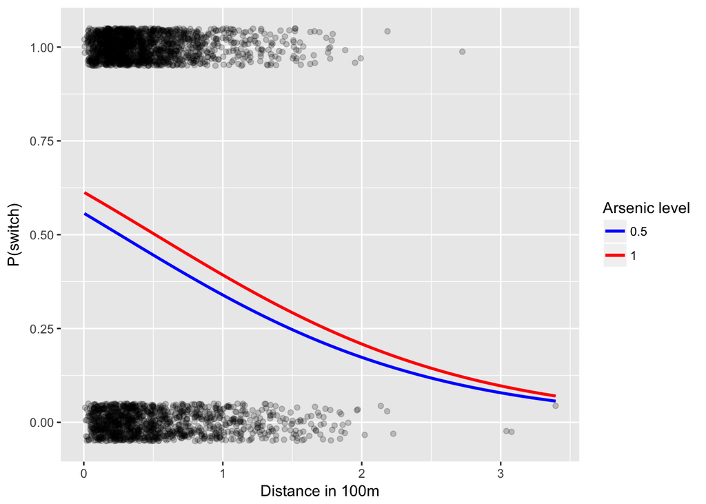

```r
#Write function that creates fitted values with one var held constant
line_2pred <- function(x, x_two,fitted_model, i, j){
  return(invlogit(coef(fitted_model)[i]*x + x_two*coef(fitted_model)[j]))
}
#Create fitted values for arsenic = 0.5&1
df$line_1 <- line_2pred(df$dist100, 0.5, fit_2, 2,3)
df$line_2 <- line_2pred(df$dist100, 1, fit_2,2,3)

#Plot fitted model for dist vs fitted
ggplot(df, aes(x=dist100)) +
  geom_jitter(data=df, aes(y=switch), alpha=0.2, height=0.05) +
  geom_smooth(data=df, aes(x=dist100, y=line_1, color='blue'),method = "glm", method.args = list(family = "binomial"), se = FALSE) +
  geom_smooth(data=df, aes(x=dist100, y=line_2, color='red'),method = "glm", method.args = list(family = "binomial"), se = FALSE) +
  scale_colour_manual(name = 'Arsenic level', values =c('blue'='blue','red'='red'), labels = c('0.5','1')) +
  xlab('Distance in 100m')+ylab('P(switch)')
```

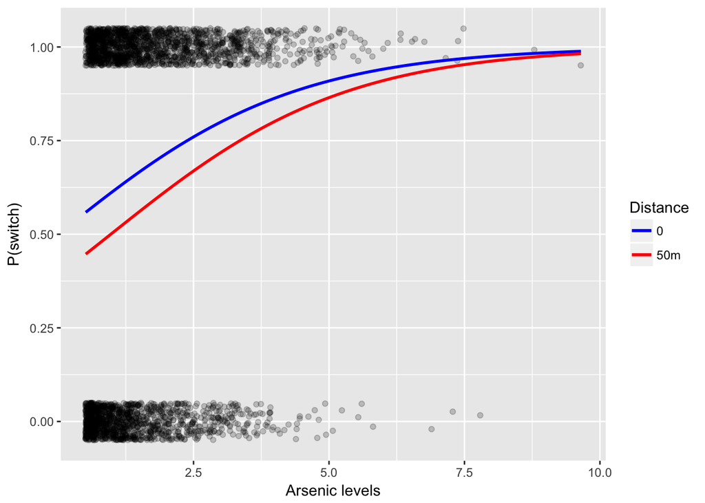

```r
#Same now for distance fixed
df$line_3 <- line_2pred(df$arsenic, 0, fit_2, 3,2)
df$line_4 <- line_2pred(df$arsenic, 0.5, fit_2,3,2)

#Plot fitted model
ggplot(df, aes(x=arsenic)) +
  geom_jitter(data=df, aes(y=switch), alpha=0.2, height=0.05) +
  geom_smooth(data=df, aes(x=arsenic, y=line_3, color='blue'),method = "glm", method.args = list(family = "binomial"), se = FALSE) +
  geom_smooth(data=df, aes(x=arsenic, y=line_4, color='red'),method = "glm", method.args = list(family = "binomial"), se = FALSE) +
  scale_colour_manual(name = 'Distance', values =c('blue'='blue','red'='red'), labels = c('0','50m')) +
  xlab('Arsenic levels')+ylab('P(switch)')
```

#### Interactions

```r
fit_3 <- glm(switch ~ dist100 + arsenic+ dist100:arsenic, family=binomial(link='logit'),df)
display(fit_3)
```

```
## glm(formula = switch ~ dist100 + arsenic + dist100:arsenic, family = binomial(link = "logit"),
##     data = df)
##                 coef.est coef.se
## (Intercept)     -0.15     0.12
## dist100         -0.58     0.21
## arsenic          0.56     0.07
## dist100:arsenic -0.18     0.10
## ---
##   n = 3020, k = 4
##   residual deviance = 3927.6, null deviance = 4118.1 (difference = 190.5)
```

$P(switch|X) = logit^{-1}(-0.15 - 0.58dist100 + 0.56arsenic - 0.18dist100xarsenic)$

We cannot interpret the intercept here since it refers to dist100=0 and arsenic=0 and there is no well with arsenic=0 among the dangerous wells. The same is true for dist100: We should not interpret it at arsenic = 0 but rather check the value for the mean of arsenic, which is 1.66. At mean levels of arsenic, the distance coefficient is $-0.58 -0.18*1.66=-0.88$. This divided by 4 yields the maximum change in P(switch=1) of ~22% at arsenic levels of 1.66. Similarly, arsenic we better interpret at a average distance, thus $0.56-0.18*0.48=0.47$. Divided by 4 we get 0.12 → at the mean distance, a 1 unit increase of arsenic corresponds to ~12% increase in P(switch=1). The interaction we can interpret as follows: With increasing arsenic levels distance gets a stronger predictor. Or: For higher distances, arsenic becomes less important as a predictor.

Now, we will see why centering makes interpretation simpler:

```r
centered <- scale(df[,c('dist100','arsenic')], center=T, scale=F)
colnames(centered) <- c('c_dist100', 'c_arsenic')
df <- cbind(df, centered)
fit_4 <- glm(switch ~ c_dist100 + c_arsenic+ c_dist100:c_arsenic, family=binomial(link='logit'),df)
display(fit_4)
```

```
## glm(formula = switch ~ c_dist100 + c_arsenic + c_dist100:c_arsenic,
##     family = binomial(link = "logit"), data = df)
##                     coef.est coef.se
## (Intercept)          0.35     0.04
## c_dist100           -0.87     0.10
## c_arsenic            0.47     0.04
## c_dist100:c_arsenic -0.18     0.10
## ---
##   n = 3020, k = 4
##   residual deviance = 3927.6, null deviance = 4118.1 (difference = 190.5)
```

As we can see, now we can directly apply the divide by 4 rule and interpret the coefficients since we directly get values that we had to calculate above! Additionally, the intercept now corresponds to $P(switch|\bar{x_1}\bar{x_2}) = logit^{-1}(35)= 0.59$. Gelman & Hill (2007) suggest to keep the interaction in the model despite it not being significant. We can see that it is almost significant and importantly, it makes sense that the coefficient is negative and also the magnitude makes sense. Therefore, we keep it in the model! We plot the interaction in the same way as before:

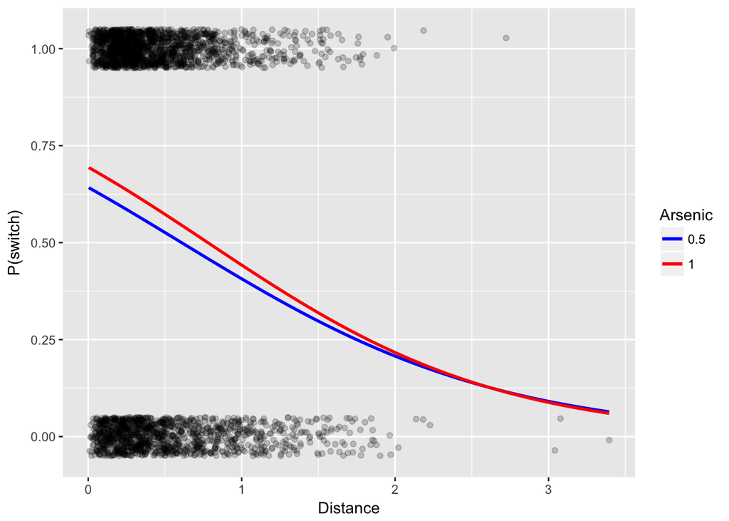

```r
#Write function for plotting
fun_2 <- function(coef_1,coef_2, coef_3, coef_4, x_2, x_3){
  return(invlogit(coef_1 + coef_2*x_2 + coef_3*x_3 + coef_4*x_2*x_3))
}

#Create fitted values
coefs <- coef(fit_4)
df$line_5 <- fun_2(coefs[1], coefs[2], coefs[3], coefs[4], df$dist100, 0.5)
df$line_6 <- fun_2(coefs[1], coefs[2], coefs[3], coefs[4], df$dist100, 1)
df$line_7 <- fun_2(coefs[1], coefs[2], coefs[3], coefs[4], 0, df$arsenic)
df$line_8 <- fun_2(coefs[1], coefs[2], coefs[3], coefs[4], 0.5, df$arsenic)
#Plot 1: P(switch) as function of distance to nearest safe well and arsenic level of existing well for the model with interaction
ggplot(df, aes(x=dist100)) +
  geom_jitter(data=df, aes(y=switch), alpha=0.2, height=0.05) +
  geom_smooth(data=df, aes(x=dist100, y=line_5, color='blue'),method = "glm", method.args = list(family = "binomial"), se = FALSE) +
  geom_smooth(data=df, aes(x=dist100, y=line_6, color='red'),method = "glm", method.args = list(family = "binomial"), se = FALSE) +
  scale_colour_manual(name = 'Arsenic', values =c('blue'='blue','red'='red'), labels = c('0.5','1')) +
  xlab('Distance')+ylab('P(switch)')
```

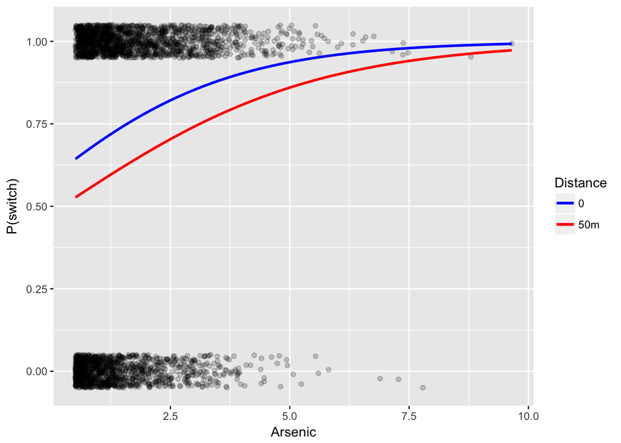

```r
#Plot
ggplot(df, aes(x=arsenic)) +
  geom_jitter(data=df, aes(y=switch), alpha=0.2, height=0.05) +
  geom_smooth(data=df, aes(x=arsenic, y=line_7, color='blue'),method = "glm", method.args = list(family = "binomial"), se = FALSE) +
  geom_smooth(data=df, aes(x=arsenic, y=line_8, color='red'),method = "glm", method.args = list(family = "binomial"), se = FALSE) +
  scale_colour_manual(name = 'Distance', values =c('blue'='blue','red'='red'), labels = c('0','50m')) +
  xlab('Arsenic')+ylab('P(switch)')
```

Obviously, the interaction is not strong.

#### Adding Social Predictors

We add educ and assoc to the model and use $educ/4$ since it makes the regression coefficient more interpretable (it then represents the predictice difference of adding four years of education):

```r
df$educ4 <- df$educ/4
fit_5 <- glm(switch ~ c_dist100 * c_arsenic + assoc + educ4 , family = binomial(link='logit'), df)
display(fit_5)
```

```
## glm(formula = switch ~ c_dist100 * c_arsenic + assoc + educ4,
##     family = binomial(link = "logit"), data = df)
##                     coef.est coef.se
## (Intercept)          0.20     0.07
## c_dist100           -0.88     0.11
## c_arsenic            0.48     0.04
## assoc               -0.12     0.08
## educ4                0.17     0.04
## c_dist100:c_arsenic -0.16     0.10
## ---
##   n = 3020, k = 6
##   residual deviance = 3905.4, null deviance = 4118.1 (difference = 212.7)
```

Assoc is not statistically significant, which is surprising. Because of the non-significance and because it does not make much sense, we remove this predictor. However, educ4 is significant and for every 4 years of difference in education, there is a change of roughly 4.25% in P(switch). So, we end up with:

```r
fit_6 <- glm(switch ~ c_dist100 * c_arsenic + educ4 , family = binomial(link='logit'), df)
display(fit_6)
```

```
## glm(formula = switch ~ c_dist100 * c_arsenic + educ4, family = binomial(link = "logit"),
##     data = df)
##                     coef.est coef.se
## (Intercept)          0.15     0.06
## c_dist100           -0.87     0.11
## c_arsenic            0.48     0.04
## educ4                0.17     0.04
## c_dist100:c_arsenic -0.16     0.10
## ---
##   n = 3020, k = 5
##   residual deviance = 3907.9, null deviance = 4118.1 (difference = 210.2)
```

Finally and interestingly, Gelman & Hill (2007) mention that it is their general practice to include interactions of the predictors if they have large main effects. I will do this in the next step:

```r
#center educ4
df$c_educ4 <-  scale(df$educ4, center=T, scale=F)
fit_7 <- glm(switch ~ c_dist100 + c_arsenic + c_educ4 + c_dist100:c_arsenic + c_dist100:c_educ4+ c_arsenic:c_educ4 , family = binomial(link='logit'), df)
display(fit_7)
```

```
## glm(formula = switch ~ c_dist100 + c_arsenic + c_educ4 + c_dist100:c_arsenic +
##     c_dist100:c_educ4 + c_arsenic:c_educ4, family = binomial(link = "logit"),
##     data = df)
##                     coef.est coef.se
## (Intercept)          0.36     0.04
## c_dist100           -0.90     0.11
## c_arsenic            0.49     0.04
## c_educ4              0.18     0.04
## c_dist100:c_arsenic -0.12     0.10
## c_dist100:c_educ4    0.32     0.11
## c_arsenic:c_educ4    0.07     0.04
## ---
##   n = 3020, k = 7
##   residual deviance = 3891.7, null deviance = 4118.1 (difference = 226.4)
```

It makes sense that education reduces the negative association between dist100 and the P(switch) and also that the association between arsenic and P(switch) gets slightly stronger with an increase in education. (Finally, Gelman & Hill (2007) bring in that we should think about standardizing all the predictors as a default option when fitting models with interactions.)

## Evaluation of a fitted logistic regression

To evaluate a logistic model we check whether the model with the predictor leads to more accurate predictions than the model without the predictor. Again I use the comparison to linear regression to illustrate the procedure:  
In linear regression, the baseline model only has the intercept $\beta_0$, which is the mean of the outcome variable. When used as an estimator, we can calculate the variance of the observed values from this baseline estimator. A statistic that reflects this variance is the *total sum of squares* (SST). We calculate it as shown below. The total sum of squares can be partitioned into the **residual sum of squares** (RSS) and the **model sum of squares** (SSM).

**Total sum of squares (SST)**:  
$SST = \sum_{i=1}^n (y_i-\bar{y})^2$

**Residual sum of squares(RSS)** or **Sum of squared errors (SSE)**:  
$RSS = \sum_{i=1}^n (y_i - \hat{y}_i)^2$

**Model Sum of Squares (SSM)** or: **Regression sum of squares (SSR)**:  
$SSM = SST - RSS = [\sum_{i=1}^n (y_i - \bar{y}_i)^2] - [\sum_{i=1}^n (y_i-\hat{y}_i)^2]$

If we have no predictors in the model, then RSS = SST. If RSS gets smaller with the inclusion of a predictor, then this is because the predictor explains some of the total variance around the base model leading to a better estimate than the mean alone. It should be clear from the above equation that SSM reflects the part of SST that the new model (the fitted regression line) can explain whereas RSS reflects the leftover that it still cannot explain. In ANOVA, the new model would be the group means of the outcome variable for each group given by the independent variable.

#### Log-likelihood, deviance and likelihood ratio

In logistic regression, deviation of observed to predicted values is reflected by the **log-likelihood** (LL):

$LL =\sum_{i=1}^N[Y_iln(\hat{Y_i}) + (1-Y_i)ln(1-\hat{Y_i})]$

The LL tells how much unexplained information there is after the model has been fitted. The larger the LL, the more unexplained information. We can therefore use the LL to compare models. In practice however, instead of the LL, we use the **deviance** (D) since this statistic follows a $\chi^2$ distribution and therefore allows hypothesis testing:

$D = -2* LL$

Gelman & Hill (2007) give helpful basic information for applying it to logistic regression:

- Deviance is a measure of error and lower deviance means better fit to data
- If we would add a predictor that is random noise, then the deviance is expected to decrease by 1 whereas we would expect it to decrease by >1 with an informative predictor (1 per predictor)

Hosmer & Lemeshow (2000) emphasize that we can think of the deviance in the same way as we think of the RSS (in the context of linear regression) when it comes to testing the significance of a model. To compare two models, we look at their difference in the deviance by calculating the **likelihood-ratio**, which follows the $\chi^2$ distribution:

$\chi^2 = -2*LL_{baseline}-(-2*LL_{new})$, with $df = k_{new} -k_{baseline}$,

where k is the number of parameters in the model. In the baseline model with no predictors, there is 1 parameter (intercept). If the $\chi^2$ statistic is significant, then the model with the added predictor explains the outcome better than the baseline model. Whereas in linear regression the baseline model is the mean, in logistic regression the baseline model with only the intercept predicts the score with the highest frequency in the dataset.

```r
#likelihood ratio for model 6/7
fit_6$deviance - fit_7$deviance
```

```
## [1] 16.16753
```

```r
# to perform the chi-square test, we can use the following package
library(lmtest)
lrtest(fit_7, fit_6)
```

|  | #Df | LogLik | Df | Chisq | Pr(>Chisq) |
| --- | --- | --- | --- | --- | --- |
| 1 | 7 | -1945.872 | NA | NA | NA |
| 2 | 5 | -1953.956 | -2 | 16.16753 | 0.0003085073 |

We see that the model is a significantly better fit. However, Gelman & Hill (2007) does not use this test in his book. He instead applies the above mentioned guidelines and looks at the individual predictors to evaluate usefulness of a model.

#### Error rate

The error rate is the rate of incorrectly predicted values. The base model always predicts the most frequent outcome. In this case, this is 42.48%. The error rate of my model *fit_7* is 37.52% If the error rate of the fitted model is similar to the base error rate, it is useless. The best possible error rate is 0. Gelman & Hill (2007) also present a model where the error rate is 36% and that is considered not very impressive. Keep in mind that the error rate does not catch differences between 0.9 and 0.51 since both would be predicted as 1. Still it is a practical measure that is easy to interpret.

#### Average predictive difference

We can compare the average difference in predicted P(Y=1|X). In the example below this is illustrated with a simpler logistic regression model of the above example. #1 shows the average predictive difference between households that are 0 or 100m away from the next safe well. #2 shows the average predictive difference between arsenic levels of 1 and 0.5. The general notation for the average predictive difference is:

$\Delta(u^{hi},u^{low}) = \frac{1}{n}\sum_{i=1}^n\delta(u^{hi},u^{low},v_i,\beta)$

And $\delta$ here is:

$\delta(u^{hi},u^{low},v_i,\beta) = P(y=1|u^{hi},v,\beta) - P(y=1|u^{lo},v,\beta)$,

where *u* corresponds to the variable we want to compare at two levels whereas *v* and $\beta$ and correspond to the input of the data and coefficients as shown in the example below:

```r
#1
fit_8 <- glm(switch ~ dist100 + arsenic + educ4, family = binomial(link='logit'), df)
b <- coef(fit_8)
hi <- 1
lo <- 0
delta <- invlogit(b[1] + b[2]*hi + b[3]*df$arsenic + b[4]*df$educ4) -
         invlogit(b[1] + b[2]*lo + b[3]*df$arsenic + b[4]*df$educ4)
m_p_diff_1 <- mean(delta)
#2
hi <- 1
lo <- 0.5
delta <- invlogit(b[1] + b[2]*df$dist100 + b[3]*hi + b[4]*df$educ4) -
         invlogit(b[1] + b[2]*df$dist100 + b[3]*lo + b[4]*df$educ4)
m_p_diff_2 <- mean(delta)
m_p_diff_2
```

```
## [1] 0.05643807
```

#### Wald statistic

The Wald statistic is analogous to the t-statistic in linear regression: Does the corresponding predictor contribute?  
$Wald=\frac{b}{SE_b}$

Since Hosmer & Lemeshow (2000) report that it can be unreliable under certain circumstances and Gelman & Hill (2007) doesn’t even mention it (though he uses the z-value for loose interpretation), I won’t further consider this statistic but rely on the likelihood ratio test for significance testing.

#### Binned residuals

I might add a description to interpret this plot later. Until then, please check for example [this resource](http://www.stat.columbia.edu/~gelman/research/published/dogs.pdf).

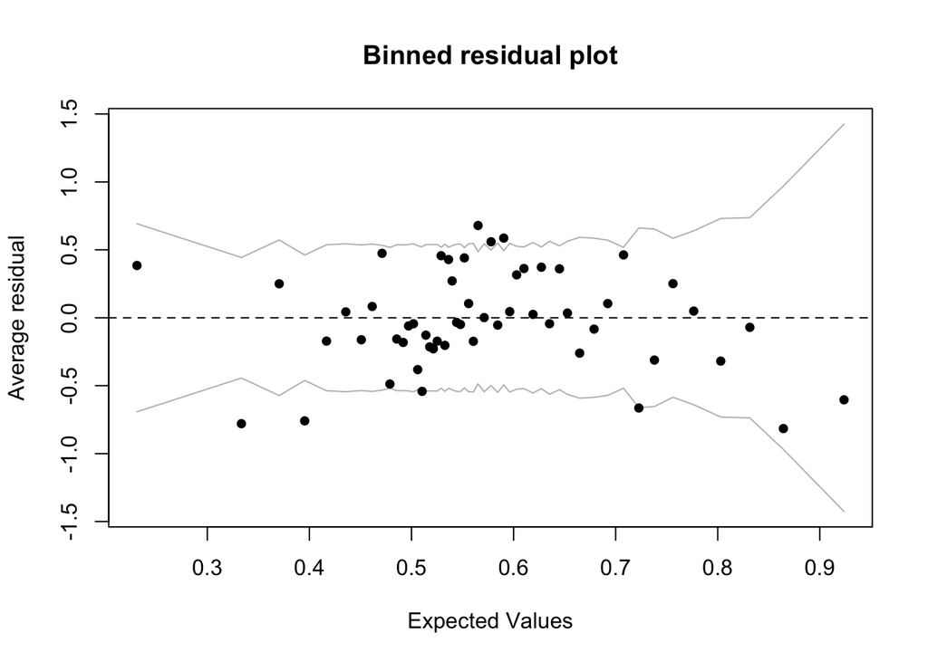

```r
binnedplot(fit_7$fitted.values, fit_7$residuals)
```

## Problems

Potential issues that can arise when fitting a logistic regression model are collinearity and *complete separation* where a predictor is completely aligned with the outcome. In the latter case, the corresponding coefficient would be $\infty$ or -$\infty$. The latter could be handled using the Bayesian or penalized-likelihood approach. I will address collinearity at a later time when I will reconsider it for linear regression. But we can check it using the *variance inflation factor*. Another issue can be *incomplete information*: If you have different categorial variables to predict Y but you miss combinations of variables, then this can lead to very high SE of the coefficients. You need ~50 participants per predictor. Therefore, watch out how complete the information in the dataset is and always look at the SE.

## Not covered in detail

These points are guidelines used by Field (2012).

#### Assumptions

1. Linearity  
   Linear relationship between continuous X and the logit of Y.  
   We can check this by looking at whether the interaction term between the predictor and its log transformation is significant.
2. Independence of Errors  
   Just as in ordinary regression, the error must be independent. Thus, the data must be independent. Check *Durban Watson Test*. Gelman & Hill (2007) mentions in the chapter about linear regression that this assumption is only important if we want to make predictions.
3. Multicollinearity  
   Predictors should not be correlated too highly (check with VIF statistics, eigenvalues of the scaled uncentered cross-products matrix)

#### Outliers:

- standardized residuals:
  - No more than 5% should have absolute values >2
  - No more than 1% should have absolute values >2.5
  - Absolute values >3 could be outlier
- Calculate average leverage (k+1)/N and look for values > 2(or 3)* the average leverage
- Look for absolute values of DFBeta>1

## Exercises

##### 1. Plotting exercise

Gelman & Hill (2007) advice to plot this WITHOUT using a computer. If you want to do this exercise, scroll down slowly so that you only can see the task, plot it and then you can compare:

###### (a) $Pr(y = 1) = logit^{-1}(x)$

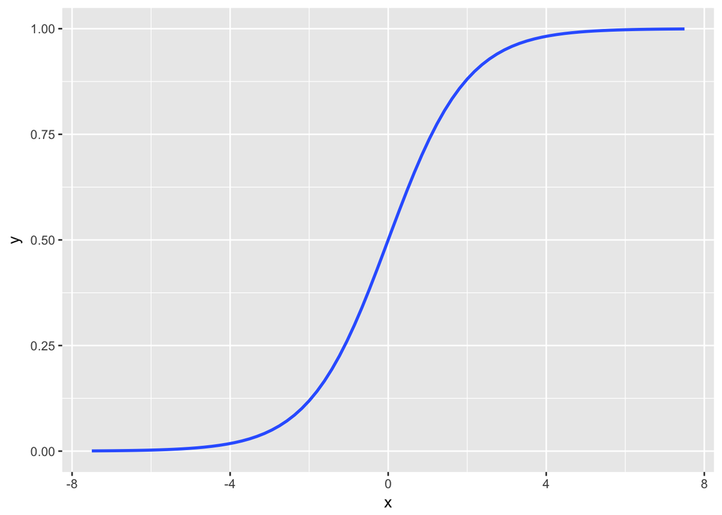

```r
library(arm)
library(ggplot2)
x <- runif(100000, -7.5, 7.5)
y <- invlogit(x)
data <- data.frame(x,y)
ggplot(data, aes(x,y)) +
  geom_smooth(method = "glm", method.args = list(family = "binomial"), se = FALSE)
```

###### (b) Pr(y = 1) = $logit^{-1}(2 + x)$

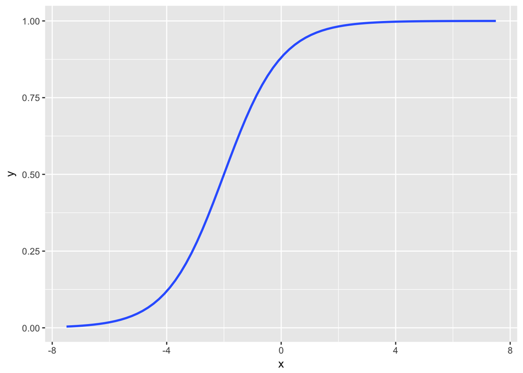

```r
y <- invlogit(2+x)
data <- data.frame(x,y)
ggplot(data, aes(x,y)) +
  geom_smooth(method = "glm", method.args = list(family = "binomial"), se = FALSE)
```

###### c) Pr(y = 1) = $logit^{-1}(2x)$

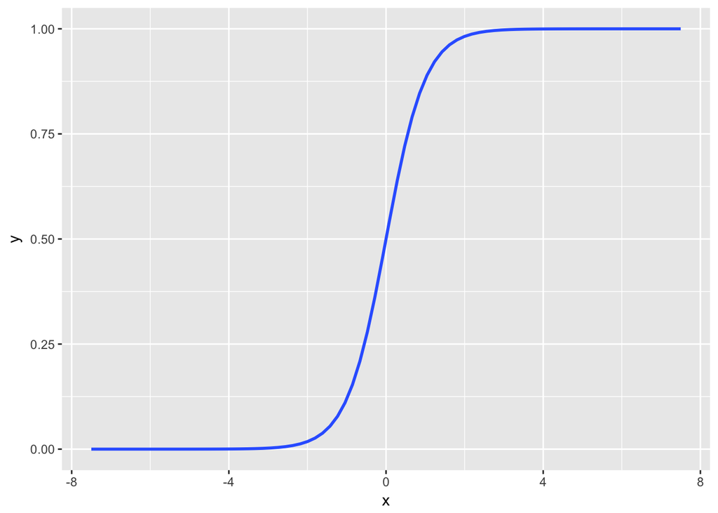

```r
y <- invlogit(2*x)
data <- data.frame(x,y)
ggplot(data, aes(x,y)) +
  geom_smooth(method = "glm", method.args = list(family = "binomial"), se = FALSE)
```

###### (d) Pr(y = 1) = $logit^{-1}(2 + 2x)$

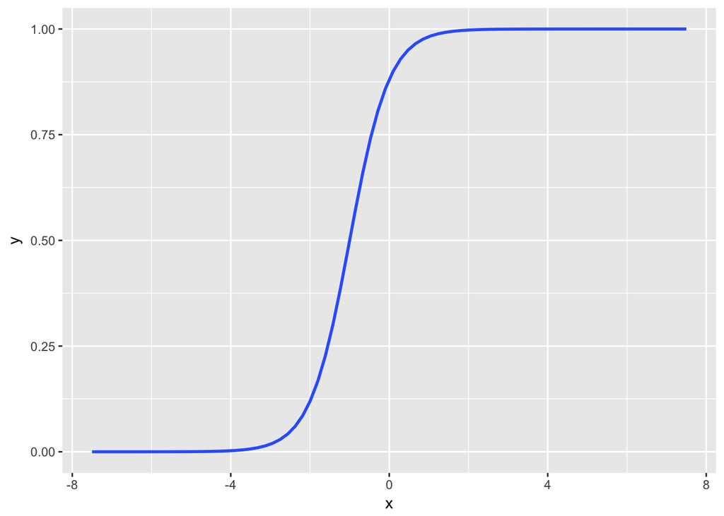

```r
y <- invlogit(2+2*x)
data <- data.frame(x,y)
ggplot(data, aes(x,y)) +
  geom_smooth(method = "glm", method.args = list(family = "binomial"), se = FALSE)
```

###### (e) Pr(y = 1) = $logit^{-1}(-2x)$

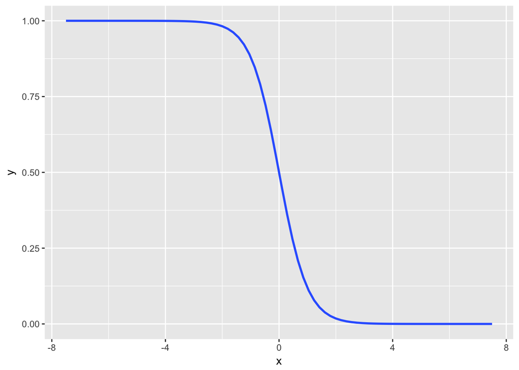

```r
y <- invlogit(-2*x)
data <- data.frame(x,y)
ggplot(data, aes(x,y)) +
  geom_smooth(method = "glm", method.args = list(family = "binomial"), se = FALSE)
```

##### 2. Earnings predict graduation

You are interested in how well the combined earnings of the parents in a child’s family predicts high school graduation. You are told that the probability a child graduates from high school is 27% for children whose parents earn no income and is 88% for children whose parents earn $60,000. Determine the logistic regression model that is consistent with this information. (For simplicity you may want to assume that income is measured in units of $10,000).

$P(gr=1|inc=0) = 0.27$  
$P(gr=0|inc=60k) = 0.88$

$P(gr=1|inc) = logit^{-1}(\beta_0 + \beta_1*INC)$

$logit^{-1}(\beta_0) = 0.27$ → $\beta_0= logit(0.27)$

$logit^{-1}(logit(0.27) + \beta_1*6) = 0.88$  
→ $\beta_1 = (logit(0.88)-logit(0.27))/6$

→ $P(gr=1|inc) = logit^{-1}(-0.995 + 0.498*income)$

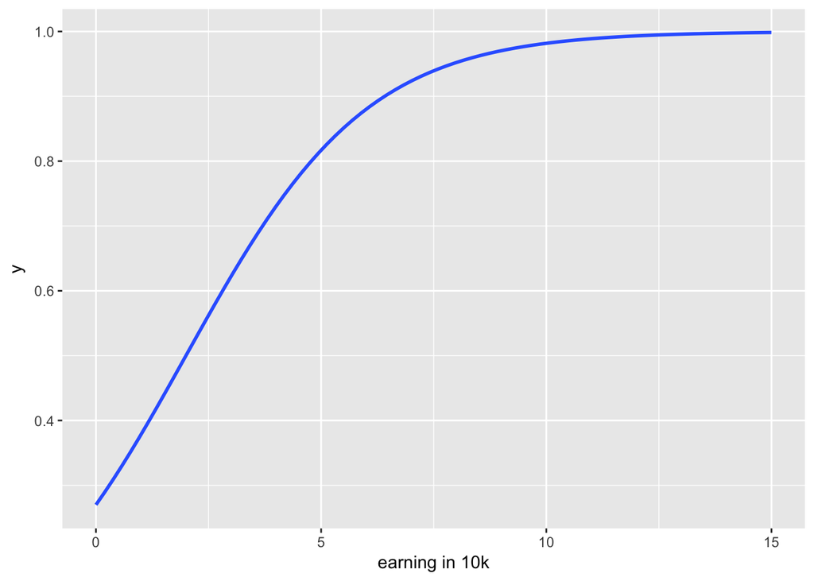

```r
x <- runif(10000, 0, 15)
y <- invlogit(-0.995 + 0.498*x)
data <- data.frame(x,y)
ggplot(data, aes(x,y)) +
  geom_smooth(method = "glm", method.args = list(family = "binomial"), se = FALSE) +
  xlab('earning in 10k')
```

##### 3. Midterm scores

In a class of 50 students, a logistic regression is performed of course grade (pass or fail) on midterm exam score (continuous values with mean 60 and standard deviation 15). The fitted model is P(pass) = $logit^{-1}(-24 + 0.4x)$.

###### (a) Graph the fitted model. Also on this graph put a scatterplot of hypothetical data consistent with the information given.

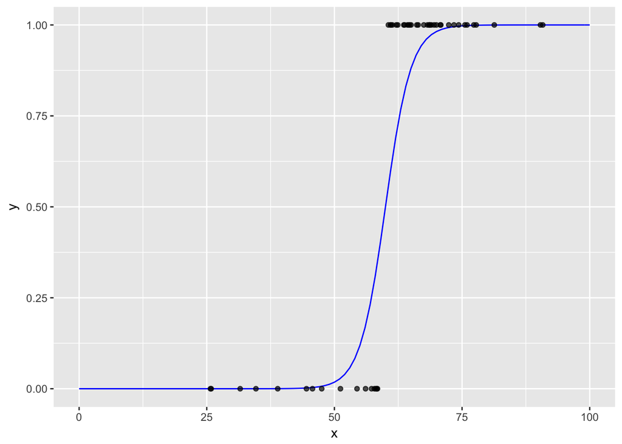

```r
midterm <- rnorm(50, 60, 15)
fitted <- invlogit(-24+0.4*midterm)
df_mt <- data.frame(midterm, fitted)
df_mt$y <- df_mt$fitted
df_mt[df_mt$fitted>0.5,'y'] <- 1
df_mt[df_mt$fitted<=0.5,'y'] <- 0
ggplot(data=data.frame(x=c(0,100)), aes(x=x)) +
  stat_function(fun=function(x) invlogit(-24 + 0.4*x), color='blue') +
  geom_point(data=df_mt, aes(x=midterm, y=y), alpha=0.7)
```

###### (b) Suppose the midterm scores were transformed to have a mean of 0 and standard deviation of 1. What would be the equation of the logistic regression using these transformed scores as a predictor?

P(pass) = $logit^{-1}(-24 + 0.4x)$  
→ $P(pass) = logit{-1}(0 + 0.4*15)$ → $P(pass) = logit{-1}(6x)$

###### c) Create a new predictor that is pure noise and implement it in the model. How much does the model change?

The deviance should decrease by ~1.

##### 4. Rodents (building a logistic regression model)

*Note:* *Will maybe add solution to this later when I find time. Currently busy with other projects…*

The folder rodents contains data on rodents in a sample of New York City apartments.

```r
rd <- read.table('http://www.stat.columbia.edu/~gelman/arm/examples/rodents/rodents.dat')
head(rd)
```

|  | borough | numunits | stories | race | personrm | housewgt | sequenceno | under6 | cd | unitflr2 | regext | totincom2 | subsidy | housing | poverty | povertyx2 | extwin4_2 | extflr5_2 | intcrack2 | inthole2 | intpeel_cat | intleak2 | duration | board2 | struct | old | help | rodent2 | foreign | … |
| --- | --- | --- | --- | --- | --- | --- | --- | --- | --- | --- | --- | --- | --- | --- | --- | --- | --- | --- | --- | --- | --- | --- | --- | --- | --- | --- | --- | --- | --- | --- |
| 65 | 1 | 10 | 4 | 3 | 0.25 | 15.13553 | 998787 | 1 | 1 | 5 | 0 | 6588 | 0 | 4 | 1 | 1 | 0 | 1 | 1 | 1 | 0 | 1 | 42 | 1 | 0 | 1 | 1 | 1 | 1 | … |
| 67 | 1 | 10 | 4 | 3 | 0.33 | 189.67769 | 174734 | 1 | 1 | 6 | NA | 15000 | 0 | 2 | 0 | 1 | 0 | 1 | 1 | 1 | 0 | 0 | 1 | 0 | 0 | 1 | 0 | 1 | 0 | … |
| 68 | 1 | 10 | 4 | 2 | 1.67 | 172.33043 | 772162 | 1 | 1 | 5 | 0 | 3808 | NA | 2 | 1 | 1 | 0 | 1 | 0 | 0 | 0 | 0 | 1 | 1 | 0 | 1 | 1 | 1 | 0 | … |
| 72 | 1 | 8 | 4 | 4 | 0.40 | 15.51273 | 7343 | 1 | 1 | 6 | 0 | 13000 | 1 | 2 | 0 | 1 | 0 | 0 | 0 | NA | 0 | 0 | 20 | 0 | 0 | 1 | 1 | 1 | 1 | … |
| 82 | 1 | 10 | 5 | 2 | 0.33 | 171.66205 | 500716 | 1 | 1 | 4 | NA | 8700 | 0 | 1 | 1 | 1 | 0 | NA | 1 | 1 | 1 | 1 | 13 | 0 | 0 | 0 | 0 | 1 | 1 | … |
| 85 | 1 | 9 | 4 | 3 | 1.00 | 178.84964 | 463351 | 2 | 1 | 3 | 1 | 19000 | 1 | 2 | 0 | 1 | 0 | 0 | 0 | 0 | 0 | 0 | 4 | 0 | 1 | 1 | 1 | 0 | 0 | … |

###### (a) Build a logistic regression model to predict the presence of rodents (the variable rodent2 in the dataset) given indicators for the ethnic groups (race). Combine categories as appropriate. Discuss the estimated coefficients in the model.

###### (b) Add to your model some other potentially relevant predictors describing the apartment, building, and community district. Build your model using the general principles explained in Section 4.6. Discuss the coefficients for the ethnicity indicators in your model.

## References

Field, A. (2012). *Discovering Statistics Using R*. SAGE Publications Ltd.

Gelman, A., & Hill, J. (2007). *Data Analysis using Regression and Multilevel/Hierarchical Models* (p. 651). https://doi.org/10.2277/0521867061

Gelman, A., & Su, Y.-S. (2016). *Arm: Data analysis using regression and multilevel/hierarchical models*. Retrieved from https://CRAN.R-project.org/package=arm

Hosmer, D. W., & Lemeshow, S. (2000). *Applied Logistic Regression*. Hoboken, NJ, USA: John Wiley & Sons, Inc. https://doi.org/10.1002/0471722146

James, G., Witten, D., Hastie, T., & Tibshirani, R. (2013). *An Introduction to Statistical Learning* (Vol. 103). New York, NY: Springer New York. https://doi.org/10.1007/978-1-4614-7138-7